# Validating primary care resource use and costs based on OMOP-mapped CPRD data against corresponding source data: the case of postmenopausal fragility fractures in the UK

Health Economics Group

Monday, 08 September 2025

# Overview

This report compares summary statistics for healthcare resource use (HCRU) and Costs between **SOURCE** and **OMOP** databases.

## Mapping specialties

The inner circle shows OMOP specialties (blue nodes), each linked to their corresponding source specialties in the outer circle (red labels). The radial length of the external dumbbell represents the difference between source and OMOP unit costs.

[figure not shown]

# Assumptions

Both CPRD_consultation and CPRD_observation tables are mapped to the OMOP visit_detail table, resulting in separate records even when they originate from the same clinical event (e.g., an observation recorded during a consultation appears as a distinct visit_detail record). Also, OMOP does not retain information about whether a visit record originated from a consultation or an observation.

Therefore, records without a provider, or with a provider lacking an assigned specialty, are excluded. We retain only one visit record per patient, per day, and per provider specialty (i.e., deduplication).

# Cohort

### Attrition

**Starting Population**

|  | Subjects (Source) | Subjects (OMOP) |
| --- | --- | --- |
| Had their first fracture in the study period when they were > 50 years old | 31,217 | 30,847 |

**Attrition Table - Exclusion Criteria**

| Reason for exclusion | Source Analysis N Subjects Excluded | Source Analysis Perc Subjects Excluded (%) | Source Analysis N Records Excluded | OMOP Analysis N Subjects Excluded | OMOP Analysis Perc Subjects Excluded (%) | OMOP Analysis N Records Excluded |
| --- | --- | --- | --- | --- | --- | --- |
| Excluding fractures happening before the birth year | 0 | 0.00 | 0 | 0 | 0.00 | 0 |
| Excluding fractures outside of study period | 0 | 0.00 | 4,599 | 0 | 0.00 | 6,026 |
| Excluding fractures outside of observation period | 25 | 0.08 | 38 |  |  |  |
| Excluding fractures on the same day as death or after death | 7 | 0.02 | 8 | 5 | 0.02 | 6 |
| Excluding fractures on the same day for the same person according to hierarchy (Hip, Spine, NHNS) | 0 | 0.00 | 6,327 |  |  |  |
| Excluding not female individuals | 0 | 0.00 | 0 | 0 | 0.00 | 0 |
| Excluding individuals without fracture records | 0 | 0.00 | 0 | 0 | 0.00 | 0 |
| Excluding individuals with index fracture after end of observation period | 3 | 0.01 | 3 | 2 | 0.01 | 2 |
| Excluding individuals with less than 730 days observation time prior to index date | 3,525 | 11.30 | 4,873 | 3,478 | 11.29 | 5,083 |
| Excluding individuals who had not turned 50 before index date | 0 | 0.00 | 0 | 0 | 0.00 | 0 |
| Excluding individuals with cancer prior or on index date | 1,857 | 6.71 | 2,365 | 1,357 | 4.96 | 1,773 |
| Excluding individuals with metabolic bone diseases prior or on index date | 131 | 0.51 | 169 | 97 | 0.37 | 130 |
| Excluding individuals with less than one month exposure | 2,563 | 9.98 | 10,509 | 2,984 | 11.53 | 12,536 |
| Number of eligible patients | 23,106 |  |  | 22,900 |  |  |

### Patients Characteristics

**Patient Characteristics**<sup>1</sup>

| Variable | CPRD Source Analysis N = 23,106 | OMOP Analysis N = 22,900 |
| --- | --- | --- |
| Age at Fracture Occurrence | 70 (61, 81) | 71 (61, 81) |
| Fracture Site |  |  |
| Hip | 3,216 (14%) | 3,197 (14%) |
| Vertebra | 1,657 (7.2%) | 1,699 (7.4%) |
| NHNV | 18,233 (79%) | 18,004 (79%) |
| Censoring Event |  |  |
| Max of 730 days from index date | 9,807 (42%) | 9,730 (42%) |
| End of Study | 6,094 (26%) | 6,026 (26%) |
| Fracture ensuing incident (index) fracture | 4,080 (18%) | 4,071 (18%) |
| End of data collection period | 1,526 (6.6%) | 1,479 (6.5%) |
| Death | 1,158 (5.0%) | 1,150 (5.0%) |
| Cancer | 375 (1.6%) | 379 (1.7%) |
| Paget’s disease of the bone, or other metabolic bone diseases | 55 (0.2%) | 54 (0.2%) |
| Max of 730 days from index date, End of Study | 7 (<0.1%) | 7 (<0.1%) |
| Cancer, Fracture ensuing incident (index) fracture | 1 (<0.1%) | 1 (<0.1%) |
| End of data collection period, Fracture ensuing incident (index) fracture | 1 (<0.1%) | 1 (<0.1%) |
| Fracture ensuing incident (index) fracture, End of Study | 1 (<0.1%) | 1 (<0.1%) |
| Max of 730 days from index date, Fracture ensuing incident (index) fracture | 1 (<0.1%) | 1 (<0.1%) |
| Follow up Time | 577 (191, 730) | 578 (192, 730) |
| Heathcare Service User Status |  |  |
| Non-User | 628 (2.7%) | 598 (2.6%) |
| User<sup>2</sup> | 22,478 (97%) | 22,302 (97%) |

<sup>1</sup> Median (Q1, Q3); n (%)  
<sup>2</sup> *User defined as subjects with >=1 clinical (i.e. non admin) encounter. Non-User were individuals with no encounters, or only admin encounters*

### Exposure

[figure not shown]

### Specialties

Total number of encounters, by specialty category.

| Source-CPRD | N = 901,535 |
| --- | --- |
| Admin | 361,678 (40%) |
| GP | 361,493 (40%) |
| Non-registered other | 122,532 (14%) |
| Nurse | 44,904 (5.0%) |
| AHP | 7,405 (0.8%) |
| Medic non-GP | 3,122 (0.3%) |
| Service | 334 (<0.1%) |
| Social | 34 (<0.1%) |
| Dental | 33 (<0.1%) |

| OMOP | N = 877,293 |
| --- | --- |
| Admin | 327,106 (37%) |
| GP | 325,922 (37%) |
| Non-registered other | 121,461 (14%) |
| Nurse | 42,557 (4.9%) |
| Uncategorised | 31,006 (3.5%) |
| Service | 22,347 (2.5%) |
| AHP | 6,651 (0.8%) |
| Medic non-GP | 236 (<0.1%) |
| Social | 7 (<0.1%) |

# HCRU

### Overall

#### **All Patients**

##### **Observed**

| Cohort | mean | min | max | sd | median | lower_q | upper_q | se | ci_lower | ci_upper |
| --- | --- | --- | --- | --- | --- | --- | --- | --- | --- | --- |
| SOURCE | 39.02 | 0 | 678 | 37.39 | 28 | 14 | 51 | 0.25 | 38.54 | 39.5 |
| OMOP | 38.31 | 0 | 678 | 36.59 | 28 | 14 | 51 | 0.24 | 37.84 | 38.78 |

##### **Bootstrap**

Confidence intervals derived using normal, basic, and percentile methods.

| Cohort | mean | variance | sd | se | ci_norm_lower | ci_norm_upper | ci_basic_lower | ci_basic_upper | ci_perc_lower | ci_perc_upper |
| --- | --- | --- | --- | --- | --- | --- | --- | --- | --- | --- |
| SOURCE | 39 | 0.06 | 0.245 | 0.008 | 38.554 | 39.514 | 38.541 | 39.508 | 38.527 | 39.493 |
| OMOP | 38.312 | 0.061 | 0.247 | 0.008 | 37.823 | 38.792 | 37.797 | 38.778 | 37.841 | 38.822 |

#### **Users Only**

##### **Observed**

| Cohort | mean | min | max | sd | median | lower_q | upper_q | se | ci_lower | ci_upper |
| --- | --- | --- | --- | --- | --- | --- | --- | --- | --- | --- |
| SOURCE | 40 | 1 | 678 | 37.44 | 29 | 15 | 52 | 0.25 | 39.51 | 40.49 |
| OMOP | 39.24 | 1 | 678 | 36.62 | 28 | 15 | 51 | 0.25 | 38.76 | 39.72 |

##### **Bootstrap**

Confidence intervals derived using normal, basic, and percentile methods.

| Cohort | mean | variance | sd | se | ci_norm_lower | ci_norm_upper | ci_basic_lower | ci_basic_upper | ci_perc_lower | ci_perc_upper |
| --- | --- | --- | --- | --- | --- | --- | --- | --- | --- | --- |
| SOURCE | 39.992 | 0.067 | 0.259 | 0.008 | 39.498 | 40.513 | 39.517 | 40.523 | 39.475 | 40.481 |
| OMOP | 39.25 | 0.065 | 0.254 | 0.008 | 38.732 | 39.728 | 38.783 | 39.755 | 38.725 | 39.697 |

### Yearly

We derived two types of mean estimates:

- Mean among *exposed patients* only: average number of visits among patients observed in each year with patients not observed in a given month excluded from the denominator (i.e., mean = (number of visits in the year) / (number of patients exposed that year)).
- Mean across *all patients* in the cohort: average number of visits per year using the full cohort as the denominator, regardless of whether patients were observed in that period. This approach assumes unobserved patients had zero visits, which may be conceptually misleading (e.g., for patients who died or were censored). However, it enables internal consistency checks: the sum of period-specific means aligns with the overall period mean because the denominator remains constant across years and is the same as the one used to derive the mean for the overall period.
- Both means are presented in the “observed” tables. Bootstrapping was conducted for the exposed-patient means only. Corresponding results for the full cohort means will be included in the appendix.
- The analysis was conducted including *partial years*, i.e., years in which patients were exposed for just part of the time

#### **All Patients**

##### **Observed**

| Cohort | year | mean_exposed | min | max | sd | q1 | median | q3 | n_exposed | tot_encounters | mean_all_patients | se | lower | upper |
| --- | --- | --- | --- | --- | --- | --- | --- | --- | --- | --- | --- | --- | --- | --- |
| SOURCE | 1 | 26.3 | 0 | 346 | 22.37 | 11 | 20 | 34 | 23106 | 607611 | 26.3 | 0.15 | 26.01 | 26.59 |
| SOURCE | 2 | 20.55 | 0 | 332 | 21.05 | 6 | 15 | 28 | 14300 | 293924 | 12.72 | 0.18 | 20.21 | 20.9 |
| OMOP | 1 | 25.81 | 0 | 346 | 21.89 | 11 | 20 | 34 | 22900 | 591125 | 25.81 | 0.14 | 25.53 | 26.1 |
| OMOP | 2 | 20.19 | 0 | 332 | 20.62 | 6 | 14 | 27 | 14172 | 286168 | 12.5 | 0.17 | 19.85 | 20.53 |

##### **Bootstrap**

Confidence intervals derived using normal, basic, and percentile methods.

| Cohort | year | mean | variance | sd | se | ci_lower_norm | ci_upper_norm | ci_lower_basic | ci_upper_basic | ci_lower_perc | ci_upper_perc |
| --- | --- | --- | --- | --- | --- | --- | --- | --- | --- | --- | --- |
| SOURCE | 1 | 26.292 | 0.02 | 0.142 | 0.004 | 26.022 | 26.58 | 26.019 | 26.565 | 26.028 | 26.575 |
| SOURCE | 2 | 20.557 | 0.031 | 0.176 | 0.006 | 20.207 | 20.897 | 20.216 | 20.909 | 20.199 | 20.892 |
| OMOP | 1 | 25.814 | 0.022 | 0.149 | 0.005 | 25.52 | 26.105 | 25.513 | 26.094 | 25.532 | 26.114 |
| OMOP | 2 | 20.193 | 0.03 | 0.174 | 0.005 | 19.852 | 20.533 | 19.848 | 20.546 | 19.839 | 20.537 |

#### **Users Only**

##### **Observed**

| Cohort | year | mean_exposed | min | max | sd | q1 | median | q3 | n_exposed | tot_encounters | mean_all_patients | se | lower | upper |
| --- | --- | --- | --- | --- | --- | --- | --- | --- | --- | --- | --- | --- | --- | --- |
| SOURCE | 1 | 26.92 | 0 | 346 | 22.36 | 12 | 21 | 35 | 22478 | 605212 | 26.92 | 0.15 | 26.63 | 27.22 |
| SOURCE | 2 | 20.71 | 0 | 332 | 21.06 | 6 | 15 | 28 | 14187 | 293878 | 13.07 | 0.18 | 20.37 | 21.06 |
| OMOP | 1 | 26.41 | 0 | 346 | 21.87 | 12 | 20 | 34 | 22302 | 589003 | 26.41 | 0.15 | 26.12 | 26.7 |
| OMOP | 2 | 20.35 | 0 | 332 | 20.63 | 6 | 15 | 28 | 14062 | 286131 | 12.83 | 0.17 | 20.01 | 20.69 |

##### **Bootstrap**

Confidence intervals derived using normal, basic, and percentile methods.

| Cohort | year | mean | variance | sd | se | ci_lower_norm | ci_upper_norm | ci_lower_basic | ci_upper_basic | ci_lower_perc | ci_upper_perc |
| --- | --- | --- | --- | --- | --- | --- | --- | --- | --- | --- | --- |
| SOURCE | 1 | 26.923 | 0.024 | 0.156 | 0.005 | 26.621 | 27.231 | 26.633 | 27.237 | 26.612 | 27.216 |
| SOURCE | 2 | 20.707 | 0.032 | 0.179 | 0.006 | 20.37 | 21.073 | 20.358 | 21.066 | 20.363 | 21.071 |
| OMOP | 1 | 26.416 | 0.023 | 0.15 | 0.005 | 26.11 | 26.699 | 26.121 | 26.717 | 26.104 | 26.7 |
| OMOP | 2 | 20.352 | 0.032 | 0.18 | 0.006 | 19.991 | 20.697 | 20.01 | 20.72 | 19.975 | 20.686 |

### Monthly

The analysis was conducted using two time-based definitions:

- *All months*: includes all calendar months in which the patient had any exposure, even if partial.
- *Full months*: includes only calendar months where the patient was fully exposed (e.g., excludes final partial month).

The results presented here are based on the “all-months” approach. Those from the the analysis restricted to full months will be included in the appendix.

Like for the yearly analysis, means were derived among *exposed patients* only: average number of visits among patients observed in each month with patients not observed in a given month excluded from the denominator (i.e., mean = (number of visits in the month) / (number of patients exposed that month)). Separately, means were also calculated across all patients in the cohort and used for internal validation (i.e., the sum of all monthly means equals the overall period). These results will be reported in the appendix.

#### **All Patients**

[figure not shown]

#### **All patients - by specialty**

Mean monthly encounters per patient by specialty category (All Patients, All Months)

[figure not shown]

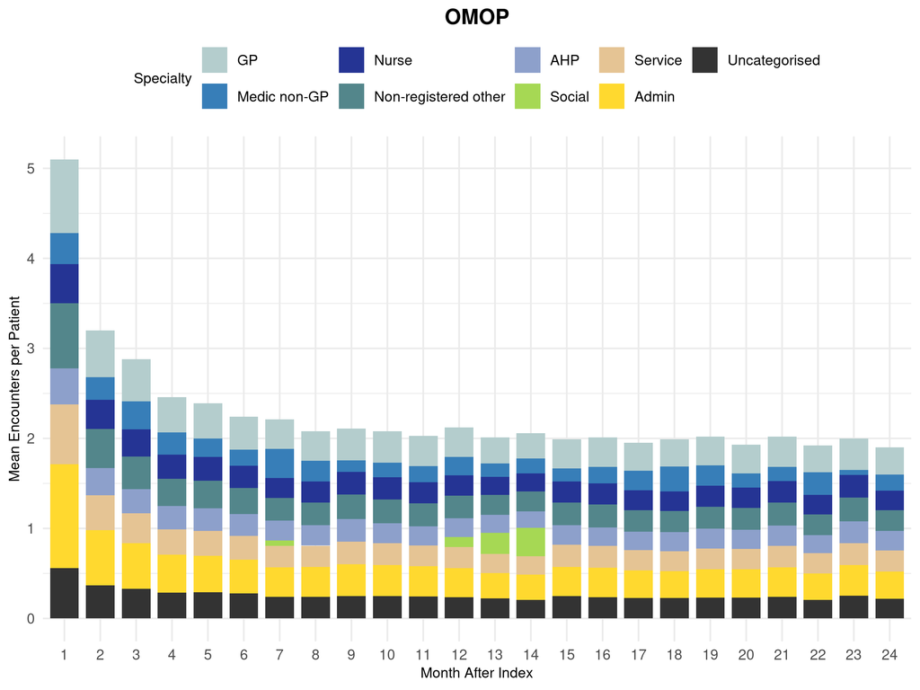

#### **Users only**

[figure not shown]

# Costs

### Overall

#### **All Patients**

##### **Observed**

| Cohort | mean | min | max | sd | median | lower_q | upper_q | se | ci_lower | ci_upper |
| --- | --- | --- | --- | --- | --- | --- | --- | --- | --- | --- |
| SOURCE | 1113.42 | 0 | 19104.33 | 1141.63 | 782.63 | 339.93 | 1508.08 | 7.51 | 1098.7 | 1128.14 |
| OMOP | 1087.13 | 0 | 19809.38 | 1116.37 | 763.51 | 331.22 | 1470.56 | 7.38 | 1072.67 | 1101.59 |

##### **Bootstrap**

Confidence intervals derived using normal, basic, and percentile methods.

| Cohort | mean | variance | sd | se | ci_norm_lower | ci_norm_upper | ci_basic_lower | ci_basic_upper | ci_perc_lower | ci_perc_upper |
| --- | --- | --- | --- | --- | --- | --- | --- | --- | --- | --- |
| SOURCE | 1112.792 | 57.186 | 7.562 | 0.239 | 1099.222 | 1128.865 | 1098.476 | 1128.562 | 1098.274 | 1128.359 |
| OMOP | 1087.052 | 54.989 | 7.415 | 0.234 | 1072.669 | 1101.737 | 1072.003 | 1101.713 | 1072.543 | 1102.253 |

#### **Users Only**

##### **Observed**

| Cohort | mean | min | max | sd | median | lower_q | upper_q | se | ci_lower | ci_upper |
| --- | --- | --- | --- | --- | --- | --- | --- | --- | --- | --- |
| SOURCE | 1144.26 | 2.59 | 19104.33 | 1142.25 | 810.56 | 368.36 | 1539.36 | 7.62 | 1129.32 | 1159.19 |
| OMOP | 1115.95 | 3.06 | 19809.38 | 1117.09 | 791.42 | 358.06 | 1494.93 | 7.48 | 1101.29 | 1130.61 |

##### **Bootstrap**

Confidence intervals derived using normal, basic, and percentile methods.

| Cohort | mean | variance | sd | se | ci_norm_lower | ci_norm_upper | ci_basic_lower | ci_basic_upper | ci_perc_lower | ci_perc_upper |
| --- | --- | --- | --- | --- | --- | --- | --- | --- | --- | --- |
| SOURCE | 1144.095 | 63.552 | 7.972 | 0.252 | 1128.792 | 1160.041 | 1128.561 | 1160.824 | 1127.688 | 1159.951 |
| OMOP | 1116.378 | 61.426 | 7.837 | 0.248 | 1100.161 | 1130.883 | 1101.295 | 1132.087 | 1099.813 | 1130.605 |

### Yearly

We derived two types of mean estimates:

- Mean among *exposed patients* only: average number of visits among patients observed in each year with patients not observed in a given month excluded from the denominator (i.e., mean = (number of visits in the year) / (number of patients exposed that year)).
- Mean across *all patients* in the cohort: average number of visits per year using the full cohort as the denominator, regardless of whether patients were observed in that period. This approach assumes unobserved patients had zero visits, which may be conceptually misleading (e.g., for patients who died or were censored). However, it enables internal consistency checks: the sum of period-specific means aligns with the overall period mean because the denominator remains constant across years and is the same as the one used to derive the mean for the overall period.
- Both means are presented in the “observed” tables. Bootstrapping was conducted for the exposed-patient means only. Corresponding results for the full cohort means will be included in the appendix.
- The analysis was conducted including *partial years*, i.e., years in which patients were exposed for just part of the time

#### **All Patients**

##### **Observed**

| Cohort | year | mean_exposed | min | max | sd | q1 | median | q3 | n_exposed | total_costs | mean_all_patients | se | lower | upper |
| --- | --- | --- | --- | --- | --- | --- | --- | --- | --- | --- | --- | --- | --- | --- |
| SOURCE | 1 | 727.9 | 0 | 16052.42 | 693.06 | 261.16 | 539.78 | 975.89 | 23106 | 16818921.2 | 727.9 | 4.56 | 718.97 | 736.84 |
| SOURCE | 2 | 622.92 | 0 | 9340 | 652.92 | 174.8 | 445.69 | 851.82 | 14300 | 8907705.7 | 385.51 | 5.46 | 612.21 | 633.62 |
| OMOP | 1 | 710.01 | 0 | 15909.51 | 676.04 | 254.94 | 529.06 | 951.77 | 22900 | 16259129.83 | 710.01 | 4.47 | 701.25 | 718.76 |
| OMOP | 2 | 609.38 | 0 | 9341.54 | 639.07 | 171.91 | 435.31 | 836.13 | 14172 | 8636096.98 | 377.12 | 5.37 | 598.85 | 619.9 |

##### **Bootstrap**

Confidence intervals derived using normal, basic, and percentile methods.

| Cohort | year | mean | variance | sd | se | ci_lower_norm | ci_upper_norm | ci_lower_basic | ci_upper_basic | ci_lower_perc | ci_upper_perc |
| --- | --- | --- | --- | --- | --- | --- | --- | --- | --- | --- | --- |
| SOURCE | 1 | 727.829 | 19.474 | 4.413 | 0.14 | 719.327 | 736.626 | 718.954 | 736.765 | 719.041 | 736.852 |
| SOURCE | 2 | 622.988 | 28.962 | 5.382 | 0.17 | 612.297 | 633.393 | 612.381 | 633.32 | 612.513 | 633.452 |
| OMOP | 1 | 709.951 | 20.774 | 4.558 | 0.144 | 701.127 | 718.994 | 701.06 | 718.798 | 701.213 | 718.952 |
| OMOP | 2 | 609.257 | 28.683 | 5.356 | 0.169 | 599.001 | 619.995 | 598.766 | 620.031 | 598.724 | 619.988 |

#### **Users Only**

##### **Observed**

| Cohort | year | mean_exposed | min | max | sd | q1 | median | q3 | n_exposed | total_costs | mean_all_patients | se | lower | upper |
| --- | --- | --- | --- | --- | --- | --- | --- | --- | --- | --- | --- | --- | --- | --- |
| SOURCE | 1 | 747.98 | 0 | 16052.42 | 692.04 | 284.32 | 560.42 | 992.36 | 22478 | 16813002.84 | 747.98 | 4.62 | 738.93 | 757.02 |
| SOURCE | 2 | 627.87 | 0 | 9340 | 653.14 | 180.5 | 449.61 | 856.25 | 14187 | 8907582.94 | 396.28 | 5.48 | 617.12 | 638.62 |
| OMOP | 1 | 728.72 | 0 | 15909.51 | 675.17 | 277.01 | 545.7 | 967.73 | 22302 | 16251961.38 | 728.72 | 4.52 | 719.86 | 737.58 |
| OMOP | 2 | 614.13 | 0 | 9341.54 | 639.29 | 176.95 | 441.46 | 840.64 | 14062 | 8635953.53 | 387.23 | 5.39 | 603.57 | 624.7 |

##### **Bootstrap**

| Cohort | year | mean | variance | sd | se | ci_lower_norm | ci_upper_norm | ci_lower_basic | ci_upper_basic | ci_lower_perc | ci_upper_perc |
| --- | --- | --- | --- | --- | --- | --- | --- | --- | --- | --- | --- |
| SOURCE | 1 | 747.963 | 23.174 | 4.814 | 0.152 | 738.553 | 757.424 | 738.603 | 757.597 | 738.355 | 757.349 |
| SOURCE | 2 | 627.665 | 30.861 | 5.555 | 0.176 | 617.186 | 638.962 | 616.597 | 638.846 | 616.893 | 639.141 |
| OMOP | 1 | 728.975 | 21.464 | 4.633 | 0.147 | 719.389 | 737.55 | 719.513 | 738.299 | 719.145 | 737.931 |
| OMOP | 2 | 614.337 | 31.789 | 5.638 | 0.178 | 602.881 | 624.982 | 603.267 | 625.324 | 602.944 | 625.002 |

### Monthly

The analysis was conducted using two time-based definitions:

- *All months*: includes all calendar months in which the patient had any exposure, even if partial.
- *Full months*: includes only calendar months where the patient was fully exposed (e.g., excludes final partial month).

The results presented here are based on the “all-months” approach. Those from the the analysis restricted to full months will be included in the appendix.

Like for the yearly analysis, means were derived among *exposed patients* only: average number of visits among patients observed in each month with patients not observed in a given month excluded from the denominator (i.e., mean = (number of visits in the month) / (number of patients exposed that month)). Separately, means were also calculated across all patients in the cohort and used for internal validation (i.e., the sum of all monthly means equals the overall period). These results will be reported in the appendix.

#### **All Patients**

[figure not shown]

#### **All patients - by specialty**

Mean monthly costs per patient by specialty category (All Patients, All Months)

[figure not shown]

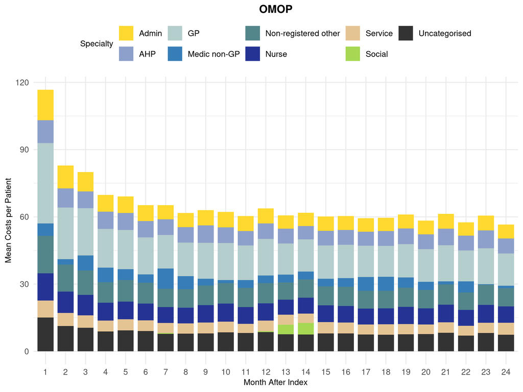

#### **Users only**

[figure not shown]

# Conclusions